# Udacity P2: Titanic data

## I - Data Discovery

```python
# Import necessary modules
import pandas as pd
from scipy import stats
from scipy.stats import f_oneway
import numpy as np
import matplotlib.pyplot as plt
import seaborn as sns
%matplotlib inline
sns.set_style("white")

# Load the data into a DataFrame
titanic_data = pd.read_csv('titanic-data.csv')

# Display the first 5 lines
titanic_data.head()
```

|  | PassengerId | Survived | Pclass | Name | Sex | Age | SibSp | Parch | Ticket | Fare | Cabin | Embarked |
| --- | --- | --- | --- | --- | --- | --- | --- | --- | --- | --- | --- | --- |
| 0 | 1 | 0 | 3 | Braund, Mr. Owen Harris | male | 22.0 | 1 | 0 | A/5 21171 | 7.2500 | NaN | S |
| 1 | 2 | 1 | 1 | Cumings, Mrs. John Bradley (Florence Briggs Th... | female | 38.0 | 1 | 0 | PC 17599 | 71.2833 | C85 | C |
| 2 | 3 | 1 | 3 | Heikkinen, Miss. Laina | female | 26.0 | 0 | 0 | STON/O2. 3101282 | 7.9250 | NaN | S |
| 3 | 4 | 1 | 1 | Futrelle, Mrs. Jacques Heath (Lily May Peel) | female | 35.0 | 1 | 0 | 113803 | 53.1000 | C123 | S |
| 4 | 5 | 0 | 3 | Allen, Mr. William Henry | male | 35.0 | 0 | 0 | 373450 | 8.0500 | NaN | S |

The dataset contains 12 columns:

- PassengerId: Passengers are assigned to a number in the dataset
- Survived: If the passenger survived (1) or not (0)
- Pclass: The class of the passenger
- Name: The name of the passenger
- Sex: The gender of the passenger
- Age: The age of the passenger
- SibSp: The number of siblings/spouses aboard the ship
- Parch: The number of parents/children aboard the ship
- Ticket: The ticket number of the pasenger
- Fare: The ticket price
- Cabin: The cabin number of the passenger
- Embarked: Where did the passengers embarked

(More information: https://www.kaggle.com/c/titanic/data)

**Let's get more information about the dataset:**

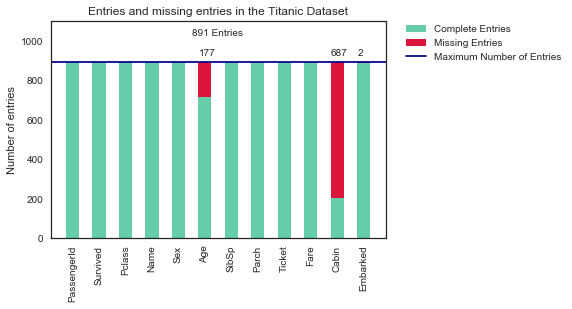

```python
# Chart plotted following matplotlib example
# (https://matplotlib.org/examples/pylab_examples/bar_stacked.html)

# Find the number of entries and missing data in each columns
# Setting up a bunch of variables
n_entries = []
n_missing_entries = []
missing_entries = []
columns = []
ind = np.arange(12)
width = 0.50

# looping through columns, collecting data
for column in titanic_data.columns:
    n_entries.append(sum(~titanic_data[column].isnull()))
    n_missing_entries.append(sum(titanic_data[column].isnull()))
    columns.append(column)
    if sum(titanic_data[column].isnull()) > 0:
        missing_entries.append('nc')
    else:
        missing_entries.append('c')

# Setting up bars and line
p1 = plt.bar(ind,
             n_entries,
             width,
             color = 'mediumaquamarine')
p2 = plt.bar(ind,
             n_missing_entries,
             width,
             bottom = n_entries,
             color = 'crimson')
l1 = plt.axhline(len(titanic_data),
                 color = 'darkblue')

# Adding labels and text
plt.ylabel('Number of entries')
plt.title('Entries and missing entries in the Titanic Dataset')
plt.xticks(ind, (columns), rotation = 90)
plt.ylim(0, 1100)
plt.yticks(np.arange(0, 1100, 200))
plt.legend((p1[0], p2[0], l1),
           ('Complete Entries', 'Missing Entries', 'Maximum Number of Entries'),
           bbox_to_anchor=(1.05, 1),
           loc=2,
           borderaxespad=0.)
plt.text(4.5, 1025,
         str(len(titanic_data)) + ' Entries')
for r, entry in enumerate(n_missing_entries):
    if entry > 0:
        plt.text(r-0.23, 925,
            entry)

# Plotting chart
plt.show()
```

On this chart we can see that the Age and Cabin columns miss a lot of values. If we did not add the number of missing values on top of the columns with missing values, we may have missed that the Embarked columns also missed some variables. (we could off course have use titanic_data.info(), but where is the fun is that)

Let's see if the data is well classified

```python
titanic_data.info()
```

```
<class 'pandas.core.frame.DataFrame'>
RangeIndex: 891 entries, 0 to 890
Data columns (total 12 columns):
PassengerId    891 non-null int64
Survived       891 non-null int64
Pclass         891 non-null int64
Name           891 non-null object
Sex            891 non-null object
Age            714 non-null float64
SibSp          891 non-null int64
Parch          891 non-null int64
Ticket         891 non-null object
Fare           891 non-null float64
Cabin          204 non-null object
Embarked       889 non-null object
dtypes: float64(2), int64(5), object(5)
memory usage: 83.6+ KB
```

All the data seems well classified, let's add some columns to make our life easier.

```python
 # Create a Survival variable from the Survived variable
titanic_data['Survival'] = titanic_data.Survived.map({0 : 'Died', 1 : 'Survived'})
# Create a Class variable from the Pclass variable
titanic_data['Class'] = titanic_data.Pclass.map({1 : 'First Class', 2 : 'Second Class', 3 : 'Third Class'})
# Create a Ports variable from the Embarked variable
titanic_data['Ports'] = titanic_data.Embarked.map({'C' : 'Cherbourg', 'Q' : 'Queenstown', 'S' : 'Southampton'})
# Create a Gender variable from the Sex variable
titanic_data['Gender'] = titanic_data.Sex.map({'male' : 'Male', 'female' : 'Female'})
# Create the Family variable by adding the SibSp and Parch variables
titanic_data['Family'] = titanic_data['SibSp'] + titanic_data['Parch']
```

## II - Data Exploration

Lot of interesting data here. Let's do some quick analysis and visualization so we can have a better feeling about the data.

First let's create a function to plot quickly the charts and print some information about the variable.

```python
# Function to calculate percentage and value in pie charts (Suggested by my reviewer)
def make_autopct(values):
    def my_autopct(pct):
        total = sum(values)
        val = int(round(pct*total/100.0))
        return '{p:.2f}%  ({v:d})'.format(p=pct,v=val)
    return my_autopct

# Function to create charts
def plot_chart(variable, kind='pie', bins = 0):

    # Takes variables of the dataframe if not inputed
    #if variable_names == {}:
    variable_names = {}
    for index in titanic_data[variable].value_counts().index:
        variable_names[index] = index

    # Plot a Pie Chart
    if kind == 'pie':

        # Make the charts bigger
        ax = plt.subplots(figsize=(6, 6))

        # Retrieves labels from the dataframe
        labels = [variable_names[category] for category in titanic_data[variable].value_counts().index]

        # Plot the chart
        titanic_data[variable].value_counts().plot(kind = kind,
                              title = variable + ' variable repartition (in %)',
                              labels = labels, colormap = 'Accent',
                              autopct=make_autopct(titanic_data.groupby(variable).size()), fontsize=10)
        plt.show()

        # Print some keys statistics
        print(variable + ' variable summary')
        for keys in variable_names.keys():
            value = len(titanic_data[titanic_data[variable] == keys])
            percent = round(100 * value / sum(~titanic_data[variable].isnull()),2)
            print(str(variable_names[keys] + ':\t' + f'{value} passengers ({percent}%).').expandtabs(25))

    # Plot an histogram
    if kind == 'hist':

        # Plot histogram when bins are not given
        if bins == 0:
            titanic_data[variable].plot(kind = kind,
                              title = variable + ' variable repartition (in %)',
                              fontsize=10)
        # Plot histogram when bins are given
        else:
            titanic_data[variable].plot(kind = kind,
                              title = variable + ' variable repartition (in %)',
                              fontsize=10, bins = bins)
        plt.show()

        # Print some keys statistics
        print(variable + ' variable summary')
        median = round(np.median(titanic_data[variable].dropna()), 2)
        mean = round(np.mean(titanic_data[variable].dropna()), 2)
        print(str('Median ' + variable + ':\t' + f'{median}.').expandtabs(25))
        print(str('Mean ' + variable + ':\t' + f'{mean}.').expandtabs(25))
```

#### 1 - The Survival variable

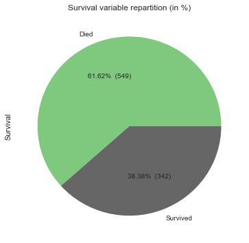

```
Survival variable summary
Died:                    549 passengers (61.62%).
Survived:                342 passengers (38.38%).
```

```python
plot_chart('Survival')
```

The Survival variable is probably one of the most important variable in the dataset.

We will, in the second part of this analysis, dive deeper into what variables influenced the most the chance of survival of passengers.

#### 2 - The Class variable

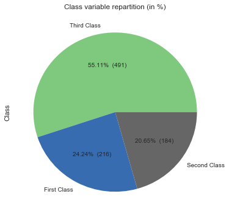

```
Class variable summary
Third Class:             491 passengers (55.11%).
First Class:             216 passengers (24.24%).
Second Class:            184 passengers (20.65%).
```

```python
plot_chart('Class')
```

It is a bit surprising to see that there were more passengers in First class than in Second class.

I expect that the Class variable had a strong influence on the Survived variable (ie. passengers in First class have higher chance of survival than passengers in Third class).

#### 3 - The Gender variable

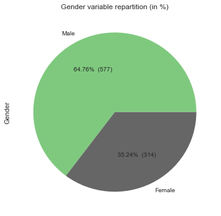

```
Gender variable summary
Male:                    577 passengers (64.76%).
Female:                  314 passengers (35.24%).
```

```python
plot_chart('Gender')
```

There are more male passengers than female, which was be expected.

I expect that the Gender variable had a strong influence on the Survived variable (ie. female passengers has higher chance of survival than male passengers).

#### 4 - The Ports variable

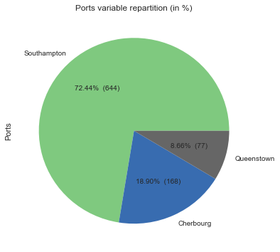

```
Ports variable summary
Southampton:             644 passengers (72.44%).
Cherbourg:               168 passengers (18.9%).
Queenstown:              77 passengers (8.66%).
```

```python
plot_chart('Ports')
```

Most passengers embarked from Southampton.

I have no specific assumptions about the impact of the port of embarkation on the chance of survival. It would be interesting to see if the Ports variable had an impact on the Survived variable.

#### 5 - The Age variable

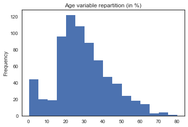

```
Age variable summary
Median Age:              28.0.
Mean Age:                29.7.
```

```python
variable = 'Age'
plot_chart(variable, kind = 'hist', bins = 16)
```

It was expected that most of the passengers would be between 18 and 35. Interestingly, there are lot of kids under the age of 5.

I expect passengers under the age of 10 to have a higher chance of survival than passengers above the age of 10.

I think this will be one of the most interesting variable to analyze.

#### 6 - The Fare variable

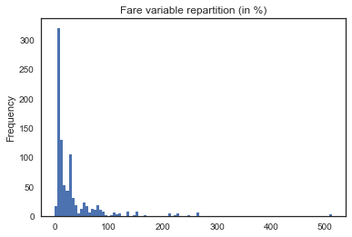

```
Fare variable summary
Median Fare:             14.45.
Mean Fare:               32.2.
```

```python
plot_chart('Fare', kind = 'hist', bins = 100)
```

Not so easy to see with an histogram, let's try with a boxplot grouped by ticket class

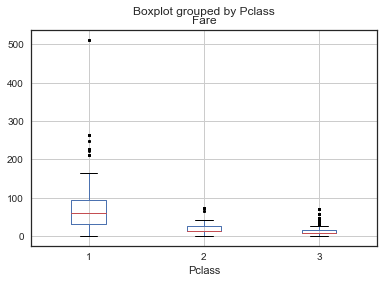

```python
# Plotting Boxplots
titanic_data.boxplot(column = 'Fare', by ='Pclass', sym='k.')
plt.show()
```

The ticket price range is wider than I expected, with one ticket worth more than $500.

Maybe even more surprising is the fact that the price range for each class greatly overlap on price < $25.

That overlap may lead the Fare to be a less informative variable than the Pclass variable.

#### 7 - Family variable

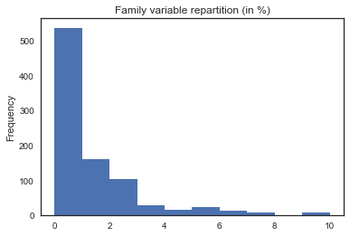

```
Family variable summary
Median Family:           0.0.
Mean Family:             0.9.
```

```python
plot_chart('Family', kind = 'hist')
```

Most of the passengers had no family abord the Titanic.

I wonder if having family aboard the Titanic had any influence of the survability.

Unfortunately we would not be able to see if family survived altogether or not since we do not have the family links.

#### 8 - The Name variable

Here let's try to do something a bit different and try get the nationality of passengers based on their names.

I decided to use the API provided by NamePrism (http://www.name-prism.com/) since, after some reserch it seems to be the best free and ready to use etchnicity classsifier.

```python
# Define function to return the ethnicity of the person
def find_ethnicity(name):

    # Keep maiden name or use 'normal' name
    if '(' in name:
        adjusted_name = name.split('(', 1)[1].split(')')[0]
        adjusted_name
    else:
        adjusted_name = name

    # Adjust characters which are not supported by Name Prism API
    adjusted_name = adjusted_name.replace("/", " ")
    adjusted_name = adjusted_name.replace(",", " ")
    titles = ['Mr.', 'Miss.', 'Master.', 'Mrs.', 'Don.', '/']
    for title in titles:
        adjusted_name = adjusted_name.replace(title, "")

    adjusted_name = adjusted_name.replace("  ", " ")

    # Create API link
    API_link = 'http://www.name-prism.com/api/' + adjusted_name.replace(' ', '%20')

    # Put the results of the query in a panda dataframe
    results = pd.read_csv(API_link, header = None)

    # Return the ethnicity which have the highest percentage and the percentage
    ethnicity = results.loc[results[1].idxmax()][0]
    percentage  = results.loc[results[1].idxmax()][1]

    # Return the ethnicity
    return ethnicity, percentage
```

Now let's run the function and store it in another dataframe.

```python
test_name_data = pd.DataFrame()
test_name_data['Name'] = titanic_data['Name']
test_name_data['Ethnicity'], test_name_data['percentage'] = zip(*titanic_data['Name'].apply(find_ethnicity))
```

Let's plot the percentage returned with the ethnicity to see how certain we are of the ethnicity of passengers.

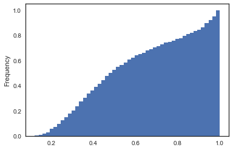

```python
test_name_data['percentage'].plot(kind='hist', bins=50, normed=True, cumulative = True)
```

We can see that the certainty of the ethnicity of passengers is evenly distributed.

We would have to determine a threshold of certainty for the passenger names.

The threshold should be:

- high enough to have a high certainty of the passengers ethnicity
- low enough to have enough passengers data to make relevant analysis

One of the most straightforward way to determine such a threshold would be to have a look at French names and see which names are 'typically' French. We will consider a name 'French' if either the first name or family names is stereotypically French.

Disclaimer: I do not pretend to know all the names used in French but still have a pretty good idea for having live there a few decades.

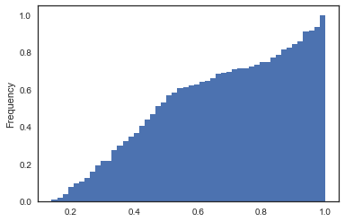

```python
test_name_data[test_name_data['Ethnicity'] == 'European-French']['percentage'].plot(kind='hist',
                                                                                    bins=50,
                                                                                    normed=True,
                                                                                    cumulative = True)
```

```python
test_name_data[(test_name_data['Ethnicity'] == 'European-French') & (test_name_data['percentage'] > 0.8)][['Name','percentage']].shape
```

```
(41, 2)
```

Few observations from looking at the french names:

- Most of them are not French or stereotypically French
- The threshold will need to be quite high in order for us to have a high certainty of the ethnicity of the passengers

Out of 158 passengers classified as French, only 37 had stereotipical French names. At a 0.8 threshold we will have 41 passengers classified as French, with 33 with stereotipical French names.

Let's see how many passengers would be left in the dataset if we use this confidence threshold.

```python
test_name_data[test_name_data['percentage'] >= 0.8]['Ethnicity'].shape
```

```
(209,)
```

Unfortunately, with only 209 passengers, we would not be able to have data relevant enough in order to make meaninful analysis.

Let's not forget that 682 passengers were not assigned ethnicity with that confidence threshold, which would dramatically change the results of our analysis if they were assigned.

Therefore, it would be difficult to continue rigourously our analysis on ethnicity/nationality with such results.

It would have been interesting to push the analysis further:

- We could have try another service provider for ethnicity and add it to our results.
- We could have labeled the dataset manually rather than with algorithm.

Since name-prism used names of emails and twitter account and assign the name based on the location, It understandably gives unreliable results for several reasons:

- Internationalization of names
- Changes in demographics

(name-prism's paper (https://arxiv.org/pdf/1708.07903.pdf))

## III - Data Analysis

Let's dive deeper into the data, but first let's define some functions to help us plot the data.

```python
def count_bar_chart(survived, did_not_survived, ind, x_labels, ymax, top_adjustment):

    # Create bars for survivors
    plt.bar(ind,
            survived,
            width = 0.95,
            color = 'mediumaquamarine')

    # Create bars for non-survivors
    plt.bar(ind,
            did_not_survived,
            bottom = survived,
            width = 0.95,
            color = 'crimson')

    # Loop through bars to write counts
    select_bar = 0
    for bar in np.arange(len(x_labels)):
        plt.text(select_bar, survived[bar]/2.25, "{:}".format(round(survived[bar], 0)), ha='center')
        plt.text(select_bar, (did_not_survived[bar]/2.25+survived[bar]), "{:}".format(round(did_not_survived[bar], 0)), ha='center', color = 'white', weight = 'bold')
        plt.text(select_bar, ((did_not_survived[bar]+survived[bar]+top_adjustment)), "{:}".format(round(did_not_survived[bar]+survived[bar], 0)), ha='center', weight = 'bold')
        select_bar += 1

    # Limit the height of the chart
    plt.ylim(ymax=ymax)
```

```python
def percent_bar_chart(survived_percent, did_not_survived_percent, ind, x_labels):

    # Create bars for survivors
    p1 = plt.bar(ind,
                 survived_percent,
                 width = 0.95,
                 color = 'mediumaquamarine')

    # Create bars for non-survivors
    p2 = plt.bar(ind,
                 did_not_survived_percent,
                 bottom = survived_percent,
                 width = 0.95,
                 color = 'crimson')

    # Loop through bars to write counts
    select_bar = 0
    for bar in np.arange(len(x_labels)):
        plt.text(select_bar, survived_percent[bar]/2.25, "{:.0%}".format(round(survived_percent[bar], 2)), ha='center')
        plt.text(select_bar, (did_not_survived_percent[bar]/2.25+survived_percent[bar]), "{:.0%}".format(round(did_not_survived_percent[bar], 2)), ha='center', color = 'white', weight = 'bold')
        select_bar += 1
```

```python
def calculate_survavibilty(dataframe, variable, x_labels):

    for label in x_labels:
        psurvived = dataframe.loc[(dataframe[variable] == label) & (dataframe['Survived'] == 1)]['Survived'].value_counts().iloc[0]
        pdid_not_survived = dataframe.loc[(dataframe[variable] == label) & (dataframe['Survived'] == 0)]['Survived'].value_counts().iloc[0]
        survived.append(psurvived)
        did_not_survived.append(pdid_not_survived)
        survived_percent.append(psurvived / len(dataframe.loc[dataframe[variable] ==label]))
        did_not_survived_percent.append(pdid_not_survived / len(dataframe.loc[dataframe[variable] ==label]))

    return psurvived
```

```python
def survived_stacked_bar_chart(dataframe, variable, order_list = []):

    # Create x_labels if empty
    x_labels = {}
    if order_list == []:
        for value in dataframe[variable].value_counts().index:
            x_labels[value] = value
    else:
        for value in order_list:
            x_labels[value] = value

    # Set up relevant variables
    ind = np.arange(len(x_labels))
    labels = x_labels.values()

    # Start empty lists
    survived = []
    survived_percent = []
    did_not_survived = []
    did_not_survived_percent = []

    # Loop through the labels to select relevant data
    for label in x_labels:
        try:
            psurvived = dataframe.loc[(dataframe[variable] == label) & (dataframe['Survived'] == 1)]['Survived'].value_counts().iloc[0]
        except:
            psurvived = 0
        try:
            pdid_not_survived = dataframe.loc[(dataframe[variable] == label) & (dataframe['Survived'] == 0)]['Survived'].value_counts().iloc[0]
        except:
            pdid_not_survived = 0
        survived.append(psurvived)
        did_not_survived.append(pdid_not_survived)
        try:
            survived_percent.append(psurvived / len(dataframe.loc[dataframe[variable] ==label]))
        except:
            survived_percent = 0
        try:
            did_not_survived_percent.append(pdid_not_survived / len(dataframe.loc[dataframe[variable] ==label]))
        except:
            did_not_survived_percent = 0

    # Set up relevant variables
    labels = x_labels.values()
    plt.subplots(figsize=(6, 8))
    ymax = 1.115 * max([survived[bar]+did_not_survived[bar] for bar in np.arange(len(x_labels))])
    top_adjustment = 0.035 * max([survived[bar]+did_not_survived[bar] for bar in np.arange(len(x_labels))])

    # Create the first chart
    plt.subplot(2, 1, 1)
    count_bar_chart(survived, did_not_survived, ind, x_labels, ymax, top_adjustment)

    # Create the legend
    plt.legend((p1[0], p2[0]),
           (['Survived', 'Did not Survived']),
           bbox_to_anchor=(1.05, 1),
           loc=2,
           borderaxespad=0.)

    # Add title to the chart
    plt.title(variable + ' Variable Stacked Bars Chart')

    # Remove x & y ticks
    plt.xticks([])
    plt.yticks([])

    # Create the second chart
    plt.subplot(2,1,2)
    percent_bar_chart(survived_percent, did_not_survived_percent, ind, x_labels)

    # Add x ticks labels and remove y tikcs
    plt.xticks(ind, (labels), rotation = 45)
    plt.yticks([])

    # Reduce the space between charts
    plt.tight_layout()
    plt.show()
```

#### 1 - The Pclass & Fare variables and Survability

Let's have a look at the relationship between the Pclass & Fare variables and the Survived variable.

First, let's have a look if we can see a relationship between the Pclass variable and the Survived using our newly written custom functions.

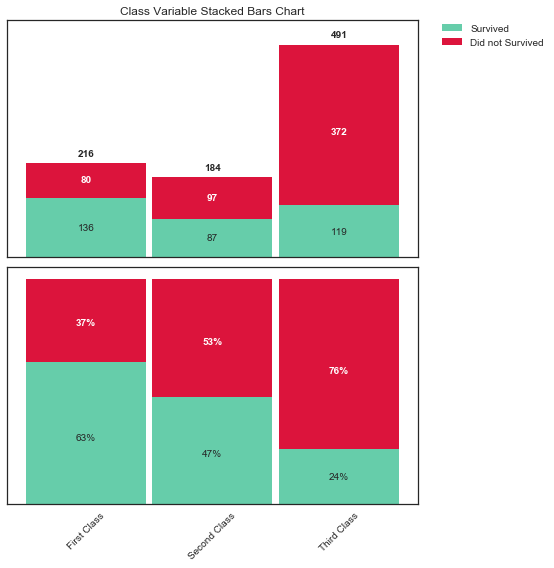

```python
survived_stacked_bar_chart(titanic_data, 'Class', ['First Class', 'Second Class', 'Third Class'])
```

As expected, there is an obvious trend here: the higher the passenger class, the higher the chance of survival.

The chance of survival roughly increase by 20% per passenger class.

let's calculate the Chi-Square to confirm our visual observation.

Null hypothesis: The Pclass variable has no impact on the Survived variable.

Alternative hypothesis: the Pclass variable has an impact on the Survived variable.

p-value level: 0.05.

```python
from scipy.stats import chi2_contingency

chi2_contingency([titanic_data[titanic_data['Survived'] == 0].groupby(['Pclass']).count()['Survived'].tolist(),
                 titanic_data[titanic_data['Survived'] == 1].groupby(['Pclass']).count()['Survived'].tolist()])
```

```
(102.88898875696056,
 4.5492517112987927e-23,
 2,
 array([[ 133.09090909,  113.37373737,  302.53535354],
        [  82.90909091,   70.62626263,  188.46464646]]))
```

the p-value of the chi-square test is way below the p-value threshold, therefore we can reject the null hypothesis: The Pclass variable has an impact on the Survived variable.

This confirm our visual observation: to have the higher chance of survival, better be in First class.

Now let's have a look at the Fare variable. First let's have a look again at the relationship between the Pclass and Fare variable.

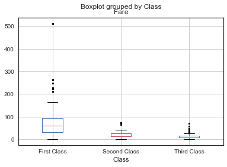

```python
titanic_data.boxplot(column = 'Fare', by ='Class', sym='k.')
```

As expected, there seems to be a relationship between the Fare and the Pclass variable. Interestingly, we can see that some passengers in third class had a higher fare than some passengers in second class. something similar happen between second class fare and first class.

Maybe even more surprising is the fact that a lot of tickets have a $0 fares. Let's investigate:

```python
titanic_data[titanic_data['Fare'] == 0]
```

|  | PassengerId | Survived | Pclass | Name | Sex | Age | SibSp | Parch | Ticket | Fare | Cabin | Embarked | Survival | Class | Ports | Gender | Family |
| --- | --- | --- | --- | --- | --- | --- | --- | --- | --- | --- | --- | --- | --- | --- | --- | --- | --- |
| 179 | 180 | 0 | 3 | Leonard, Mr. Lionel | male | 36.0 | 0 | 0 | LINE | 0.0 | NaN | S | Died | Third Class | Southampton | Male | 0 |
| 263 | 264 | 0 | 1 | Harrison, Mr. William | male | 40.0 | 0 | 0 | 112059 | 0.0 | B94 | S | Died | First Class | Southampton | Male | 0 |
| 271 | 272 | 1 | 3 | Tornquist, Mr. William Henry | male | 25.0 | 0 | 0 | LINE | 0.0 | NaN | S | Survived | Third Class | Southampton | Male | 0 |
| 277 | 278 | 0 | 2 | Parkes, Mr. Francis "Frank" | male | NaN | 0 | 0 | 239853 | 0.0 | NaN | S | Died | Second Class | Southampton | Male | 0 |
| 302 | 303 | 0 | 3 | Johnson, Mr. William Cahoone Jr | male | 19.0 | 0 | 0 | LINE | 0.0 | NaN | S | Died | Third Class | Southampton | Male | 0 |
| 413 | 414 | 0 | 2 | Cunningham, Mr. Alfred Fleming | male | NaN | 0 | 0 | 239853 | 0.0 | NaN | S | Died | Second Class | Southampton | Male | 0 |
| 466 | 467 | 0 | 2 | Campbell, Mr. William | male | NaN | 0 | 0 | 239853 | 0.0 | NaN | S | Died | Second Class | Southampton | Male | 0 |
| 481 | 482 | 0 | 2 | Frost, Mr. Anthony Wood "Archie" | male | NaN | 0 | 0 | 239854 | 0.0 | NaN | S | Died | Second Class | Southampton | Male | 0 |
| 597 | 598 | 0 | 3 | Johnson, Mr. Alfred | male | 49.0 | 0 | 0 | LINE | 0.0 | NaN | S | Died | Third Class | Southampton | Male | 0 |
| 633 | 634 | 0 | 1 | Parr, Mr. William Henry Marsh | male | NaN | 0 | 0 | 112052 | 0.0 | NaN | S | Died | First Class | Southampton | Male | 0 |
| 674 | 675 | 0 | 2 | Watson, Mr. Ennis Hastings | male | NaN | 0 | 0 | 239856 | 0.0 | NaN | S | Died | Second Class | Southampton | Male | 0 |
| 732 | 733 | 0 | 2 | Knight, Mr. Robert J | male | NaN | 0 | 0 | 239855 | 0.0 | NaN | S | Died | Second Class | Southampton | Male | 0 |
| 806 | 807 | 0 | 1 | Andrews, Mr. Thomas Jr | male | 39.0 | 0 | 0 | 112050 | 0.0 | A36 | S | Died | First Class | Southampton | Male | 0 |
| 815 | 816 | 0 | 1 | Fry, Mr. Richard | male | NaN | 0 | 0 | 112058 | 0.0 | B102 | S | Died | First Class | Southampton | Male | 0 |
| 822 | 823 | 0 | 1 | Reuchlin, Jonkheer. John George | male | 38.0 | 0 | 0 | 19972 | 0.0 | NaN | S | Died | First Class | Southampton | Male | 0 |

Most of the passengers with a 0$ fare did not survived regardless of Class.

Let's go deeper and see if the chance of survival is different depending on the fare inside each class (limited the fare to $300 to remove outliers).

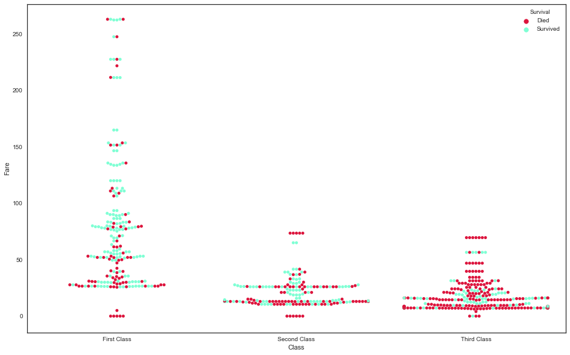

```python
plt.subplots(figsize=(16, 10))
sns.swarmplot('Class',
              'Fare',
              data=titanic_data[titanic_data['Fare'] < 300],
              hue = 'Survival',
              order = ['First Class', 'Second Class', 'Third Class'],
              palette = {'Died': '#DC143C' , 'Survived': '#7fffd4' })
```

It is very obvious on the swarmplot that the chance of survival increase with the class.

It seems that in First and Second class, a higher fare might give you a better chance of survival. This does not seems to be the case in third class.

Let's verify the hypothesis with one way ANOVA tests.

First, let's start with the relationship between the Fare and the Survived variable.

null hypothesis: There is no relationship between the Fare and the Survived variable.

alternative hypothesis: There is a relationship between the Fare and the Survived variable.

p-value: 0.05

```python
f_oneway(titanic_data[titanic_data['Survived'] == 0]['Fare'].tolist(),
         titanic_data[titanic_data['Survived'] == 1]['Fare'].tolist())
```

```
F_onewayResult(statistic=63.030764228044482, pvalue=6.1201893419218733e-15)
```

The p-value is below the 0.05 threshold therefore the one way ANOVA test confirmed our intuition that there is a relationship between the Fare and the Survived variable.

Let's now have a look at the effect of the Fare variable on the Survived variable inside the different classes.

null hypothesis: there is no relationship between the Fare and Survived variable inside a specific class.

alternative hypothesis: there is a relationship between the Fare and Survived variable inside a specific class.

p-value: 0.05

```python
for pclass in [1,2,3]:
    print(str(pclass) + ' class one way ANOVA test:')
    print(f_oneway(titanic_data[(titanic_data['Pclass'] == pclass) & (titanic_data['Survived'] == 0)]['Fare'].tolist(),
                     titanic_data[(titanic_data['Pclass'] == pclass) & (titanic_data['Survived'] == 1)]['Fare'].tolist()))
```

```
1 class one way ANOVA test:
F_onewayResult(statistic=8.0995644842355397, pvalue=0.004858011186235532)
2 class one way ANOVA test:
F_onewayResult(statistic=1.7877991334735683, pvalue=0.18286333148735787)
3 class one way ANOVA test:
F_onewayResult(statistic=0.00042250950053052073, pvalue=0.98360899339697849)
```

Interestlingly, the Fare variable only have an impact on the Survived variable within the first class.

CONCLUSION:

- The chance of survival greatly increase by class (a 20% jump in chance of surviving per class).
- The chance of survival increase with higher fares.
- The chance of survival increase in first class with higher fares.

#### 2 - The Sex variable and Survability

Now let's have a look at the relationship between the Sex and survived variable

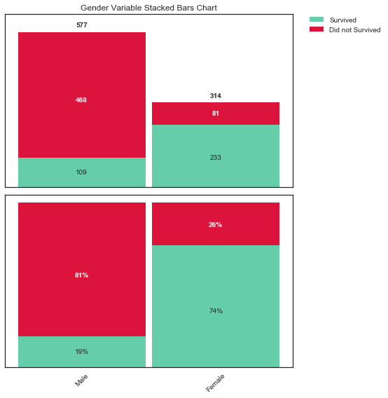

```python
survived_stacked_bar_chart(titanic_data, 'Gender')
```

There seems to be a strong relationship between the passenger gender and its chance of survival.

Let's test the relationship with a chi square test.

null hypothesis: There is no relationship between the Sex and the Survived variable.

alternative hypothesis: There is a relationship between the Sex and the Survived variable.

p-value: 0.05

```python
chi2_contingency([titanic_data[titanic_data['Survived'] == 0].groupby(['Sex']).count()['Survived'].tolist(),
                 titanic_data[titanic_data['Survived'] == 1].groupby(['Sex']).count()['Survived'].tolist()])
```

```
(260.71702016732104,
 1.1973570627755645e-58,
 1,
 array([[ 193.47474747,  355.52525253],
        [ 120.52525253,  221.47474747]]))
```

Again, no surprises here, the chi square test confirmed that there is a relationship between the Sex and the Survived variable.

Let's go further and see if the class and the gender have a combined effect on survival.

But first, let's define a new function!

```python
def filtered_stacked_bar_charts(dataframe, variable, variable_group_by, x_order = [],  c_order = []):

    # Create c_labels if empty
    c_labels = {}
    if c_order == []:
        for value in dataframe[variable_group_by].value_counts().index:
            c_labels[value] = value
    else:
        for value in c_order:
            c_labels[value] = value

    # Create x_labels if empty
    x_labels ={}
    if x_order == []:
        for value in dataframe[variable].value_counts().index:
            x_labels[value] = value
    else:
        for value in x_order:
            x_labels[value] = value

    # Set up relevant variables
    num_subplots = len(c_labels)
    plt.subplots(figsize=(15, 8))

    # Loop through variables to create charts
    for chart, c_label in zip(np.arange(num_subplots), c_labels):
        survived = []
        survived_percent = []
        did_not_survived = []
        did_not_survived_percent = []

        # Loop through the labels to select relevant data
        for label in x_labels:

            try:
                psurvived = dataframe.loc[(dataframe[variable] == label) & (dataframe['Survived'] == 1) & (dataframe[variable_group_by] == c_label)]['Survived'].value_counts().iloc[0]
            except:
                psurvived = 0

            try:
                pdid_not_survived = dataframe.loc[(dataframe[variable] == label) & (dataframe['Survived'] == 0)& (dataframe[variable_group_by] == c_label)]['Survived'].value_counts().iloc[0]
            except:
                pdid_not_survived = 0


            survived.append(psurvived)
            did_not_survived.append(pdid_not_survived)

            try:
                survived_percent.append(psurvived / len(dataframe.loc[(dataframe[variable] ==label) & (dataframe[variable_group_by] == c_label)]))
            except:
                survived_percent = 0
            try:
                did_not_survived_percent.append(pdid_not_survived / len(dataframe.loc[(dataframe[variable] ==label) & ((dataframe[variable_group_by] == c_label))]))
            except:
                did_not_survived_percent = 0

        # Set up relevant variables
        ind = np.arange(len(x_labels))
        ymax = 1.115*max([sum(titanic_data.loc[(titanic_data[variable] == x_label) &
                                               (titanic_data[variable_group_by] == c_label)]['Survived'].value_counts())
                          for x_label in x_labels
                          for c_label in c_labels])
        top_adjustment = ymax / 25

        # Create the first chart
        plt.subplot(2,num_subplots,chart +1)
        count_bar_chart(survived, did_not_survived, ind, x_labels, ymax, top_adjustment)

        # Add title to the chart
        plt.title(variable + " Variable by " + str(c_labels[c_label]))

        # Remove x & y ticks
        plt.xticks([])
        plt.yticks([])

        # Create the second chart
        plt.subplot(2,num_subplots,chart +1 + num_subplots)
        percent_bar_chart(survived_percent, did_not_survived_percent, ind, x_labels)

        # Add x ticks labels and remove y tikcs
        plt.xticks(ind, (label for label in x_labels.values()), rotation = 45)
        plt.yticks([])

        # Reduce the space between charts
        plt.tight_layout()
    plt.legend((p1[0], p2[0]),
           (['Survived', 'Did not Survived']),
           bbox_to_anchor=(1.05, 1),
           loc=2,
           borderaxespad=0.)
```

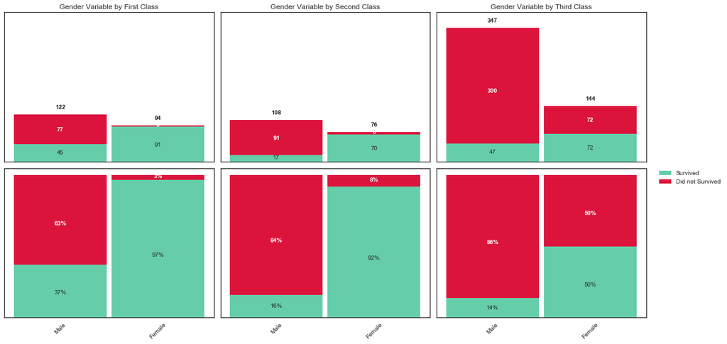

```python
filtered_stacked_bar_charts(titanic_data,
                            'Gender',
                            'Class',
                             c_order = ['First Class', 'Second Class', 'Third Class'])
```

Very interesting differences between gender chances of survival.

Female travelling in Third class had a better chance of surviving than male travelling in First class.

Maybe even more interesting is the fact that women travelling in second class had almost had twice more chance of surviving than women in third class.

We do not observe the same bump for male between third and second class but between men in first and second class. Men in first class had more twice more chance of surviving than men in second class.

CONCLUSION:

- The chance of survival is greater for female.
- Female in third class had higher chance of survival than male in any class.
- Female in first and second class had their chance of survival almost multiply by 2 compared to female in third class.
- Male in first class had their chance of survival multiply by to compared to male in second and third class.

#### 3 - The Embarked variable and Survability

Now let's see if the port of embarkation had effect on the chance of survival.

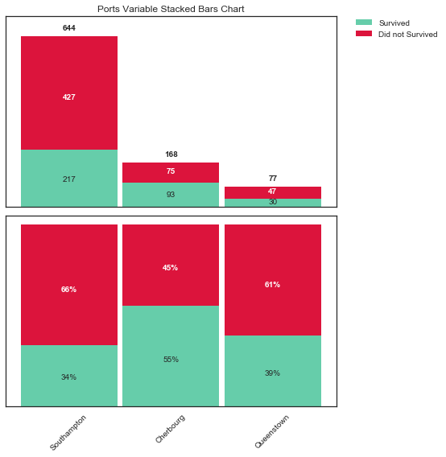

```python
survived_stacked_bar_chart(titanic_data, 'Ports')
```

Apparently the port of embarkation had an impact on the chance of survival.

Let's make a chi square test of independence to confirm:

null hypothesis: There is no relationship between the Embarked and the Survived variable.

alternative hypothesis: There is a relationship between the Embarked and the Survived variable.

p-value: 0.05

```python
chi2_contingency([titanic_data[titanic_data['Survived'] == 0].groupby(['Embarked']).count()['Survived'].tolist(),
                 titanic_data[titanic_data['Survived'] == 1].groupby(['Embarked']).count()['Survived'].tolist()])
```

```
(26.489149839237619,
 1.769922284120912e-06,
 2,
 array([[ 103.7480315,   47.5511811,  397.7007874],
        [  64.2519685,   29.4488189,  246.2992126]]))
```

The Chi square test confirmed our visual observation: there is a relationship between the Embarked and the Survived variable.

Let's go deeper and see if one of the variable we already encountered could explain this relationship or if passengers that embarked from Cherbourg were just better at swimming.

Let's start with the Pclass variable.

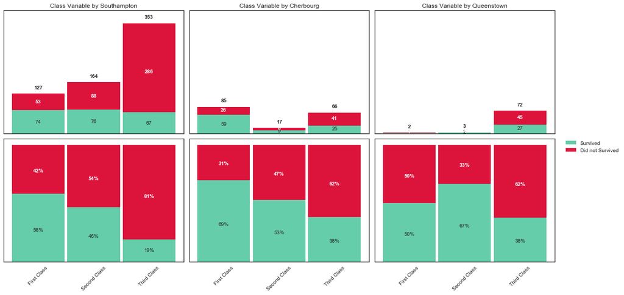

```python
filtered_stacked_bar_charts(titanic_data,
                            'Class',
                            'Ports',
                            x_order = ['First Class', 'Second Class', 'Third Class'])
```

These charts give really good insights that could explain why passengers from Cherbourg had a higher chance of survival than passengers from both Southamption and Queensland:

- Almost all the passengers from Queenstown were in third class and more than half of the passengers embarking at Southampton were in third class
- More than half of the passengers from Cherbourg were in first class.

In addition we can see than the chance of survival between third class passengers from Queenstown and Southampton are vastly different.

Now let's have a look at the Sex variable.

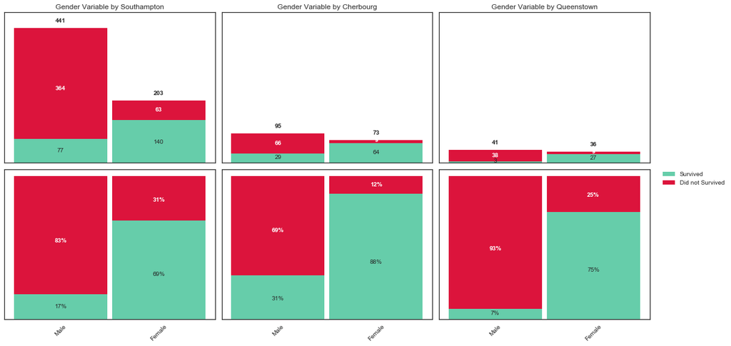

```python
filtered_stacked_bar_charts(titanic_data,
                            'Gender',
                            'Ports')
```

Interesting:

- Cherbourg passengers were almost 45% female
- Queenstown passengers were more than 45% female
- Southampton passengers were more than 30% female

This, combined with our previous finding, help us understand why passengers from Cherbourg had higher chance of survival: High percentage of First class and high percentage of female.

The high female percentage can also explain why passengers from Queenstown had a higher chance of survival than passengers from Southampton.

CONCLUSION:

- The difference in survivablity from the Embarked variable seems to be explained by the class and gender repartition boarding inside the Titanic.

#### 4 - The Age variable and Survability

Now let's see if the Age variable had an influence on survability.

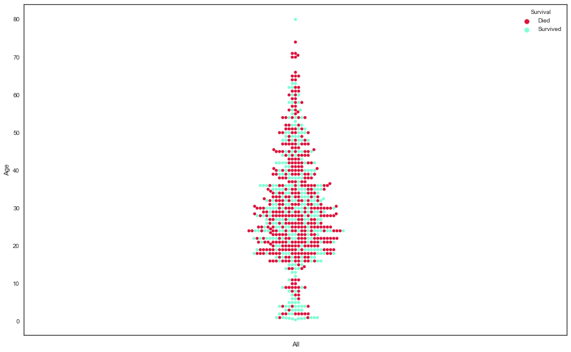

```python
plt.subplots(figsize=(16, 10))
titanic_data['All'] = ''
sns.swarmplot(x = 'All',
              y = 'Age',
              hue = 'Survival',
              data = titanic_data,
              palette = {'Died': '#DC143C' , 'Survived': '#7fffd4' })
```

Interestingly, we can see that it seems that passengers under 15 have way better chance to survive.

Let's see if the Age variable has a relationship with the Survived variable with a one way ANOVA tests.

null hypothesis: There is no relationship between the Age and the Survived variable.

alternative hypothesis: There is a relationship between the Age and the Survived variable.

p-value: 0.05

But first let's drop the rows which have no data.

```python
titanic_data_temp_age = titanic_data[['Age', 'Survived', 'Sex']]
titanic_data_temp_age = titanic_data_temp_age.dropna(subset = ['Age'])

f_oneway(titanic_data_temp_age[titanic_data_temp_age['Survived'] == 0]['Age'].tolist(),
         titanic_data_temp_age[titanic_data_temp_age['Survived'] == 1]['Age'].tolist())
```

```
F_onewayResult(statistic=4.2711949338159041, pvalue=0.039124654013483327)
```

the p-value is under 0.05, therefore we can reject the null hypothesis.

The Age variable has an influence on the Survived variable.

Let's dive deeper into the Age variable by looking at its relationship with the Sex variable.

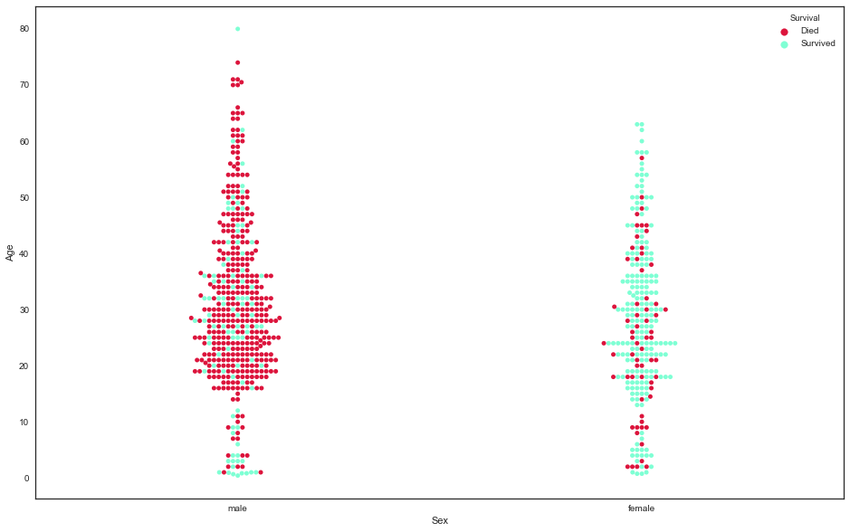

```python
plt.subplots(figsize=(16, 10))
sns.swarmplot(x = 'Sex',
              y = 'Age',
              hue = 'Survival',
              data = titanic_data,
              palette = {'Died': '#DC143C' , 'Survived': '#7fffd4' })
```

Male passengers under the age of 15 have a better chance of surviving than any other male age group.

Female passengers seems to roughly have the same chance of survival accross all age group.

Let's dvelve down on passengers under the age of 15.

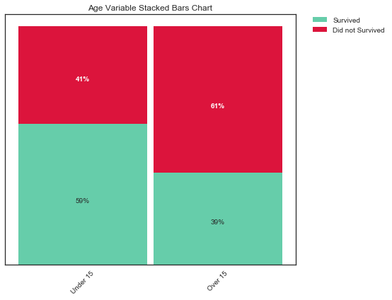

```python
# Could probably have make a nice function here

# Crunch numbers for targeted groups
survived_under_15 = len(titanic_data_temp_age[(titanic_data_temp_age['Age'] <= 15) & (titanic_data_temp_age['Survived'] == 1)]['Age'])
did_not_survived_under_15 = len(titanic_data_temp_age[(titanic_data_temp_age['Age'] <= 15) & (titanic_data_temp_age['Survived'] == 0)]['Age'])
survived_over_15 = len(titanic_data_temp_age[(titanic_data_temp_age['Age'] >= 15) & (titanic_data_temp_age['Survived'] == 1)]['Age'])
did_not_survived_over_15 = len(titanic_data_temp_age[(titanic_data_temp_age['Age'] >= 15) & (titanic_data_temp_age['Survived'] == 0)]['Age'])

# Calculate percentages
survived_under_15_percent = survived_under_15 / len(titanic_data_temp_age.loc[(titanic_data_temp_age['Age'] <= 15)])
did_not_survived_under_15_percent = did_not_survived_under_15 / len(titanic_data_temp_age.loc[(titanic_data_temp_age['Age'] <= 15)])
survived_over_15_percent = survived_over_15 /  len(titanic_data_temp_age.loc[(titanic_data_temp_age['Age'] >= 15)])
did_not_survived_over_15_percent = did_not_survived_over_15 / len(titanic_data_temp_age.loc[(titanic_data_temp_age['Age'] >= 15)])

# Append results in lists for plotting
survived = []
survived.append(survived_under_15_percent)
survived.append(survived_over_15_percent)
did_not_survived = []
did_not_survived.append(did_not_survived_under_15_percent)
did_not_survived.append(did_not_survived_over_15_percent)

# Make the chart bigger
plt.subplots(figsize=(6, 6))

# Create bars for survivors
p1 = plt.bar([0,1],
                 survived,
                 width = 0.95,
                 color = 'mediumaquamarine')

# Create bars for non-survivors
p2 = plt.bar([0,1],
                 did_not_survived,
                 bottom = survived,
                 width = 0.95,
                 color = 'crimson')

# Loop through bars to write counts
x_labels = ['Survived', 'Did not survived']
select_bar = 0
for bar in np.arange(len(x_labels)):
        plt.text(select_bar, survived[bar]/2.25, "{:.0%}".format(round(survived[bar], 2)), ha='center')
        plt.text(select_bar, (did_not_survived[bar]/2.25+survived[bar]), "{:.0%}".format(round(did_not_survived[bar], 2)), ha='center', color = 'white', weight = 'bold')
        select_bar += 1

plt.title('Age Variable Stacked Bars Chart')

# Add x ticks labels and remove y tikcs
plt.xticks([0,1], (['Under 15', 'Over 15']), rotation = 45)
plt.yticks([])

# Reduce the space between charts
plt.tight_layout()

# Add legend
plt.legend((p1[0], p2[0]),
           (['Survived', 'Did not Survived']),
           bbox_to_anchor=(1.05, 1),
           loc=2,
           borderaxespad=0.)

plt.show()
```

Passengers under the age of 15 had a higher chance of surviving than passengers over 15.

There is almost an 20% difference!

Let's see the difference by gender now.

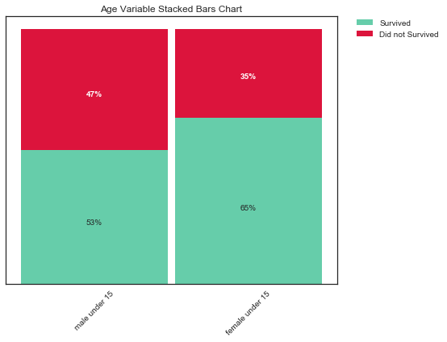

```python
# Crunch numbers for targeted groups
survived_under_15_male = len(titanic_data_temp_age[(titanic_data_temp_age['Age'] <= 15) & (titanic_data_temp_age['Survived'] == 1) & (titanic_data_temp_age['Sex'] == 'male')]['Age'])
did_not_survived_under_15_male = len(titanic_data_temp_age[(titanic_data_temp_age['Age'] <= 15) & (titanic_data_temp_age['Survived'] == 0) & (titanic_data_temp_age['Sex'] == 'male')]['Age'])
survived_under_15_female = len(titanic_data_temp_age[(titanic_data_temp_age['Age'] <= 15) & (titanic_data_temp_age['Survived'] == 1) & (titanic_data_temp_age['Sex'] == 'female')]['Age'])
did_not_survived_under_15_female = len(titanic_data_temp_age[(titanic_data_temp_age['Age'] <= 15) & (titanic_data_temp_age['Survived'] == 0) & (titanic_data_temp_age['Sex'] == 'female')]['Age'])

# Calculate percentages
survived_under_15_male_percent = survived_under_15_male / len(titanic_data_temp_age.loc[(titanic_data_temp_age['Age'] <= 15) &  (titanic_data_temp_age['Sex'] == 'male')])
did_not_survived_under_15_male_percent = did_not_survived_under_15_male / len(titanic_data_temp_age.loc[(titanic_data_temp_age['Age'] <= 15) & (titanic_data_temp_age['Sex'] == 'male')])
survived_under_15_female_percent = survived_under_15_female /  len(titanic_data_temp_age.loc[(titanic_data_temp_age['Age'] <= 15) & (titanic_data_temp_age['Sex'] == 'female')])
did_not_survived_under_15_female_percent = did_not_survived_under_15_female / len(titanic_data_temp_age.loc[(titanic_data_temp_age['Age'] <= 15) & (titanic_data_temp_age['Sex'] == 'female')])

# Append results in lists for plotting
survived = []
survived.append(survived_under_15_male_percent)
survived.append(survived_under_15_female_percent)
did_not_survived = []
did_not_survived.append(did_not_survived_under_15_male_percent)
did_not_survived.append(did_not_survived_under_15_female_percent)

# Make the Chart bigger
plt.subplots(figsize=(6, 6))

# Create bars for survivors
p1 = plt.bar([0,1],
                 survived,
                 width = 0.95,
                 color = 'mediumaquamarine')

# Create bars for non-survivors
p2 = plt.bar([0,1],
                 did_not_survived,
                 bottom = survived,
                 width = 0.95,
                 color = 'crimson')

# Loop through bars to write counts
x_labels = ['Survived', 'Did not survived']
select_bar = 0
for bar in np.arange(len(x_labels)):
        plt.text(select_bar, survived[bar]/2.25, "{:.0%}".format(round(survived[bar], 2)), ha='center')
        plt.text(select_bar, (did_not_survived[bar]/2.25+survived[bar]), "{:.0%}".format(round(did_not_survived[bar], 2)), ha='center', color = 'white', weight = 'bold')
        select_bar += 1

plt.title('Age Variable Stacked Bars Chart')

# Add x ticks labels and remove y tikcs
plt.xticks([0,1], (['male under 15', 'female under 15']), rotation = 45)
plt.yticks([])

# Reduce the space between charts
plt.tight_layout()

# Add legend
plt.legend((p1[0], p2[0]),
           (['Survived', 'Did not Survived']),
           bbox_to_anchor=(1.05, 1),
           loc=2,
           borderaxespad=0.)

plt.show()
```

This chart is very interesting for 2 reasons:

First, it shows that the difference of chance of survival between male and female passengers under 15 is way smaller than for the total of the passengers (reminder: male: 19% female: 74%)

Second, it raises an weird point, whereas the chance of survival for male under 15 greatly improve compare to their older counterpart, females under 15 have a lower chance of survival than the general female population.

Let's investigate why the female under 15 have a lower chance of survival than the one over (if we can).

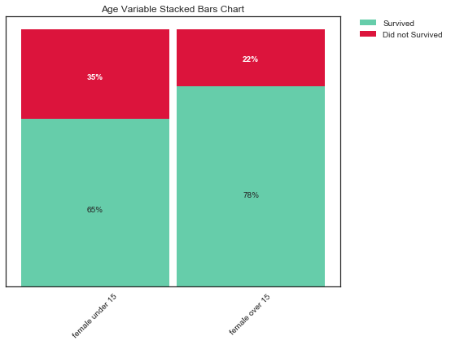

```python
# Crunch numbers for targeted groups
survived_under_15_female = len(titanic_data_temp_age[(titanic_data_temp_age['Age'] <= 15) & (titanic_data_temp_age['Survived'] == 1) & (titanic_data_temp_age['Sex'] == 'female')]['Age'])
did_not_survived_under_15_female = len(titanic_data_temp_age[(titanic_data_temp_age['Age'] <= 15) & (titanic_data_temp_age['Survived'] == 0) & (titanic_data_temp_age['Sex'] == 'female')]['Age'])
survived_over_15_female = len(titanic_data_temp_age[(titanic_data_temp_age['Age'] >= 15) & (titanic_data_temp_age['Survived'] == 1) & (titanic_data_temp_age['Sex'] == 'female')]['Age'])
did_not_survived_over_15_female = len(titanic_data_temp_age[(titanic_data_temp_age['Age'] >= 15) & (titanic_data_temp_age['Survived'] == 0) & (titanic_data_temp_age['Sex'] == 'female')]['Age'])

# Calculate percentages
survived_under_15_female_percent = survived_under_15_female / len(titanic_data_temp_age.loc[(titanic_data_temp_age['Age'] <= 15) &  (titanic_data_temp_age['Sex'] == 'female')])
did_not_survived_under_15_female_percent = did_not_survived_under_15_female / len(titanic_data_temp_age.loc[(titanic_data_temp_age['Age'] <= 15) & (titanic_data_temp_age['Sex'] == 'female')])
survived_over_15_female_percent = survived_over_15_female /  len(titanic_data_temp_age.loc[(titanic_data_temp_age['Age'] >= 15) & (titanic_data_temp_age['Sex'] == 'female')])
did_not_survived_over_15_female_percent = did_not_survived_over_15_female / len(titanic_data_temp_age.loc[(titanic_data_temp_age['Age'] >= 15) & (titanic_data_temp_age['Sex'] == 'female')])

# Append results in lists for plotting
survived = []
survived.append(survived_under_15_female_percent)
survived.append(survived_over_15_female_percent)
did_not_survived = []
did_not_survived.append(did_not_survived_under_15_female_percent)
did_not_survived.append(did_not_survived_over_15_female_percent)

# Make a bigger chart
plt.subplots(figsize=(6, 6))

# Create bars for survivors
p1 = plt.bar([0,1],
                 survived,
                 width = 0.95,
                 color = 'mediumaquamarine')

# Create bars for non-survivors
p2 = plt.bar([0,1],
                 did_not_survived,
                 bottom = survived,
                 width = 0.95,
                 color = 'crimson')

# Loop through bars to write counts

x_labels = ['Survived', 'Did not survived']
select_bar = 0
for bar in np.arange(len(x_labels)):
        plt.text(select_bar, survived[bar]/2.25, "{:.0%}".format(round(survived[bar], 2)), ha='center')
        plt.text(select_bar, (did_not_survived[bar]/2.25+survived[bar]), "{:.0%}".format(round(did_not_survived[bar], 2)), ha='center', color = 'white', weight = 'bold')
        select_bar += 1

plt.title('Age Variable Stacked Bars Chart')

# Add x ticks labels and remove y tikcs
plt.xticks([0,1], (['female under 15', 'female over 15']), rotation = 45)
plt.yticks([])

# Reduce the space between charts
plt.tight_layout()

# Add legend
plt.legend((p1[0], p2[0]),
           (['Survived', 'Did not Survived']),
           bbox_to_anchor=(1.05, 1),
           loc=2,
           borderaxespad=0.)

plt.show()
```

```python
print("Pclass variable for female under 15")
print(titanic_data.loc[(titanic_data['Age'] <= 15) & (titanic_data['Sex'] == 'female')]['Pclass'].value_counts())
print("Pclass variable for female over 15")
print(titanic_data.loc[(titanic_data['Age'] >= 15) & (titanic_data['Sex'] == 'female')]['Pclass'].value_counts())
```

```
Pclass variable for female under 15
3    30
2    10
1     3
Name: Pclass, dtype: int64
Pclass variable for female over 15
1    83
3    75
2    64
Name: Pclass, dtype: int64
```

We can see why there was a discrepancy between survival for female under 15 and female over 15.

It seems to be simply due to the passengers class. More female passengers under 15 were in third class proportionaly to female over 15.

To conclude:

- Male passengers under 15 had a better chance of surviving than the older male passengers.
- Female passengers under 15 had a lower chance of surviving than the older female passengers.
- Male passengers under 15 still had a lower chance of surviving than their female counterparts.

#### 6 - The Family variable and Survivability

And finally, let's have a look at the relationship between the Family variable and the Survived variable.

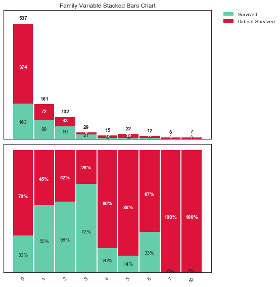

```python
survived_stacked_bar_chart(titanic_data, 'Family', [0, 1, 2, 3, 4, 5, 6, 7, 10])
```

We can see some very interesting trends here. However, due to the low number of occurence for passengers having more than 3 family members (under 25), I think it would be best to only look at passengers with 3 family members aboard the Titanic or less.

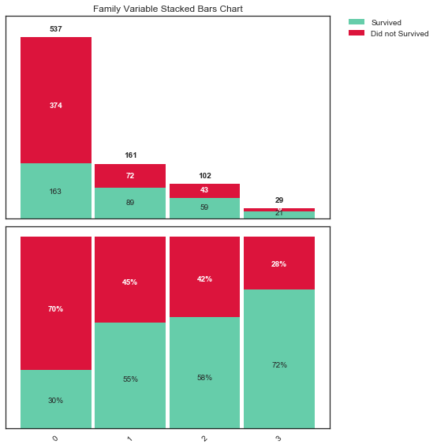

```python
survived_stacked_bar_chart(titanic_data, 'Family', [0, 1, 2, 3])
```

The trend here is very interesting, we can see that passengers travelling alone had lower chance of survival and passengers with 3 family members aboard had higher chance of survival.

Could it be explained by other factors?

Let's have a look at the Pclass variable first.

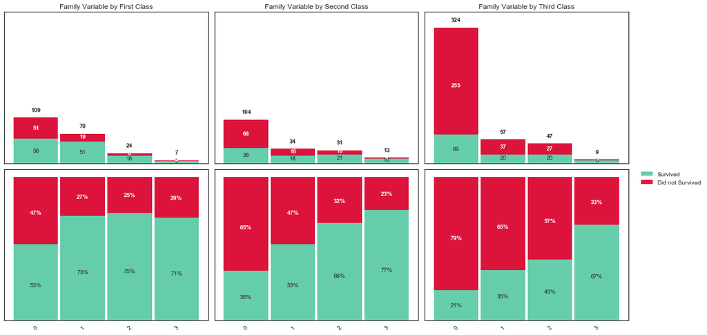

```python
filtered_stacked_bar_charts(titanic_data,
                            'Family',
                            'Class',
                            c_order = ["First Class", "Second Class", "Third Class"],
                            x_order = [0, 1, 2, 3])
```

We do observe a similar trend when looking through the Pclass variable.

Let's now have a look at the Sex variable.

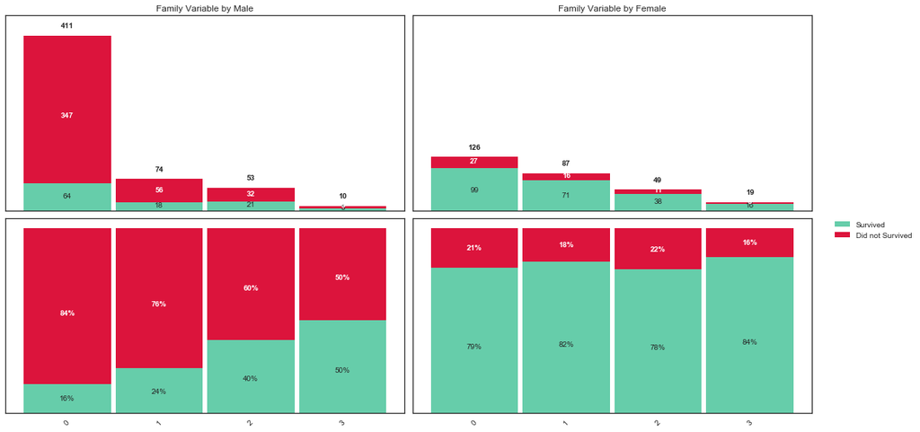

```python
filtered_stacked_bar_charts(titanic_data,
                            'Family',
                            'Gender',
                            x_order = [0, 1, 2, 3])
```

There were around 3 times more men travelling without family than women travelling without family. There were around the same amount of men and women travelling with one or two family members. There were around 2 times more women travelling with 3 family members than men.

This can definitely explain the trend we were seing earlier.

## II - Conclusion

```python
print(titanic_data[(titanic_data['Pclass'] == 1) & (titanic_data['Fare'] >= 100) & (titanic_data['Sex'] == 'female')]['Survived'].value_counts(normalize=True))
print(titanic_data[(titanic_data['Pclass'] == 3) & (titanic_data['Age'] >= 15) & (titanic_data['Sex'] == 'male')]['Survived'].value_counts(normalize=True))
```

```
1    0.941176
0    0.058824
Name: Survived, dtype: float64
0    0.871681
1    0.128319
Name: Survived, dtype: float64
```

Conclusion:

Best case scenario:

- First Class
- Higher Fare
- Female Chance of survival: 94.11%

Worst Case scenario:

- Third Class
- Male
- Over 15 Chance of survival: 12.83%

Final remarks:

- The titanic dataset only represent a fraction of the titanic passengers and we cannot know if we can generalize it to the entire passengers population.
- It would have been interesting to have a complete cabin variable to make an interesting representation to see if cabin distance had an impact on chance of survival.